# Exploratory Analysis of Earthquakes Worldwide in the Last 30 Days

## Context

This data set is taken from USGS(U.S Geological Survey). The USGS provides reliable scientific information to describe and understand the Earth; minimize loss of life and property from natural disasters; manage water, biological, energy, and mineral resources; and enhance and protect our quality of life.

As part of it's program, USGS monitors and reports on earthquakes, assesses earthquake impacts and hazards, and conducts targeted research on the causes and effects of earthquakes. The USGS provides real-time notifications, feeds and web services about earthquakes just after they happen. Further details can be found in the link below,

https://earthquake.usgs.gov/earthquakes/feed/

## Content

The data set contains details of all earthquakes that have happened in the last 30 days and is updated every 15 mins in the USGS website. I have uploaded this data set with update settings to weekly levels. The data dictionary.

Below are the fields included in the CSV format:

- `depth`- Depth of the event in kilometers. The depth where the earthquake begins to rupture. This depth may be relative to the WGS84 geoid, mean sea-level, or the average elevation of the seismic stations which provided arrival-time data for the earthquake location.
- `depthError`- Uncertainty of reported depth of the event in kilometers.
- `dmin` - Horizontal distance from the epicenter to the nearest station (in degrees). 1 degree is approximately 111.2 kilometers. In general, the smaller this number, the more reliable is the calculated depth of the earthquake.
- `gap` - The largest azimuthal gap between azimuthally adjacent stations (in degrees). In general, the smaller this number, the more reliable is the calculated horizontal position of the earthquake. Earthquake locations in which the azimuthal gap exceeds 180 degrees typically have large location and depth uncertainties.
- `horizontalError` - Uncertainty of reported location of the event in kilometers.
- `id` - A unique identifier for the event. This is the current preferred id for the event, and may change over time. See the "ids" GeoJSON format property.
- `latitude` - Decimal degrees latitude. Negative values for southern latitudes.
- `locationSource` - The network that originally authored the reported location of this event.
- `longitude` - Decimal degrees longitude. Negative values for western longitudes.
- `mag` - The magnitude for the event. Earthquake magnitude is a measure of the size of an earthquake at its source.
- `magError`- Uncertainty of reported magnitude of the event.
- `magNst` - The total number of seismic stations used to calculate the magnitude for this earthquake.
- `magSource` - Network that originally authored the reported magnitude for this event.
- `magType` - The method or algorithm used to calculate the preferred magnitude for the event.
- `net` - The ID of a data contributor. Identifies the network considered to be the preferred source of information for this event.
- `nst` - The total number of seismic stations used to determine earthquake location.
- `place` - Textual description of named geographic region near to the event. This may be a city name, or a Flinn-Engdahl Region name. If there is no nearby city within 300 kilometers (or if the nearby cities database is unavailable for some reason), the Flinn-Engdahl (F-E) seismic and geographical regionalization scheme is used.
- `rms` - The root-mean-square (RMS) travel time residual, in sec, using all weights. This parameter provides a measure of the fit of the observed arrival times to the predicted arrival times for this location. Smaller numbers reflect a better fit of the data.
- `status` - Indicates whether the event has been reviewed by a human. Status is either automatic or reviewed. Automatic events are directly posted by automatic processing systems and have not been verified or altered by a human. Reviewed events have been looked at by a human. The level of review can range from a quick validity check to a careful reanalysis of the event.
- `time` - Time when the event occurred. Times are reported in milliseconds since the epoch ( 1970-01-01T00:00:00.000Z), and do not include leap seconds. In certain output formats, the date is formatted for readability.
- `type` - Type of seismic event.
- `updated` - Time when the event was most recently updated. Times are reported in milliseconds since the epoch.

```python
#import modules to use later on
import pandas as pd
import numpy as np
import matplotlib.pyplot as plt
import seaborn as sns
import geopandas as gpd

earthquakes = pd.read_csv('all_month.csv')

#check that the data has been loaded correctly
num_rows, num_cols = earthquakes.shape
print(f'This dataset has {num_rows} rows and {num_cols} columns')
```

```
This dataset has 9184 rows and 22 columns
```

First, we check the contents of the dataset by looking at the first 5 rows.

```python
earthquakes.head()
```

|  | time | latitude | longitude | depth | mag | magType | nst | gap | dmin | rms | ... | updated | place | type | horizontalError | depthError | magError | magNst | status | locationSource | magSource |
| --- | --- | --- | --- | --- | --- | --- | --- | --- | --- | --- | --- | --- | --- | --- | --- | --- | --- | --- | --- | --- | --- |
| 0 | 2021-12-02T02:37:46.010Z | 38.809666 | -122.797669 | 2.080000 | 0.83 | md | 8.0 | 85.00000 | 0.002508 | 0.02 | ... | 2021-12-02T02:39:19.857Z | 5km NW of The Geysers, CA | earthquake | 0.33 | 1.65 | NaN | 1.0 | automatic | nc | nc |
| 1 | 2021-12-02T02:26:50.000Z | 50.234000 | 178.712000 | 42.000000 | 5.40 | Mi | 17.0 | 244.79998 | 1.201048 | 1.29 | ... | 2021-12-02T02:32:23.802Z | Rat Islands, Aleutian Islands, Alaska | earthquake | 0.00 | 0.00 | NaN | 5.0 | reviewed | at | at |
| 2 | 2021-12-02T02:23:37.216Z | 61.413700 | -151.692800 | 89.500000 | 1.60 | ml | NaN | NaN | NaN | 0.61 | ... | 2021-12-02T02:35:01.018Z | 44 km NW of Beluga, Alaska | earthquake | NaN | 0.80 | NaN | NaN | automatic | ak | ak |
| 3 | 2021-12-02T02:15:50.505Z | 60.644500 | -148.007400 | 18.500000 | 1.50 | ml | NaN | NaN | NaN | 0.90 | ... | 2021-12-02T02:26:49.081Z | 39 km ESE of Whittier, Alaska | earthquake | NaN | 0.30 | NaN | NaN | automatic | ak | ak |
| 4 | 2021-12-02T02:11:42.370Z | 19.169167 | -155.482666 | 30.540001 | 2.20 | ml | 42.0 | 93.00000 | NaN | 0.14 | ... | 2021-12-02T02:17:12.860Z | 3 km S of Pāhala, Hawaii | earthquake | 0.54 | 0.92 | 4.05 | 5.0 | automatic | hv | hv |

5 rows × 22 columns

Below, we look for any null values in the dataset.

```python
earthquakes.isnull().sum()
```

```
time                  0
latitude              0
longitude             0
depth                 0
mag                   2
magType               2
nst                2571
gap                1538
dmin               2718
rms                   1
net                   0
id                    0
updated               0
place                 0
type                  0
horizontalError    2398
depthError            1
magError           2104
magNst             1545
status                0
locationSource        0
magSource             0
dtype: int64
```

There are several columns with null values. We should explore these null values in more detail and decide whether to include them in our analysis. We could replace the null values with 0 values, replace them with the average values for each respective variable or delete them altogether. For the purposes of our exploratory analysis, we will keep the null values.

Next, we create a correlation matrix from the dataset to check for any strong correlations between any particular variables that we should explore more.

```
                 latitude  longitude     depth       mag       nst       gap  \
latitude         1.000000  -0.440425 -0.273390 -0.555248 -0.458625  0.074804
longitude       -0.440425   1.000000  0.154217  0.586007 -0.134664 -0.125083
depth           -0.273390   0.154217  1.000000  0.383120  0.358013 -0.015294
mag             -0.555248   0.586007  0.383120  1.000000  0.476251 -0.069819
nst             -0.458625  -0.134664  0.358013  0.476251  1.000000 -0.348831
gap              0.074804  -0.125083 -0.015294 -0.069819 -0.348831  1.000000
dmin            -0.602230   0.393842  0.246766  0.532192 -0.093457 -0.042421
rms             -0.036796   0.303502  0.324279  0.590040  0.235146 -0.063064
horizontalError -0.624977   0.630273  0.535828  0.758976 -0.236584  0.030820
depthError      -0.055657   0.077090  0.065178  0.069753 -0.087499  0.093082
magError        -0.098817  -0.207446  0.014959 -0.001035  0.242145  0.088016
magNst          -0.211795   0.258120  0.237948  0.446238  0.596360 -0.150780

                     dmin       rms  horizontalError  depthError  magError  \
latitude        -0.602230 -0.036796        -0.624977   -0.055657 -0.098817
longitude        0.393842  0.303502         0.630273    0.077090 -0.207446
depth            0.246766  0.324279         0.535828    0.065178  0.014959
mag              0.532192  0.590040         0.758976    0.069753 -0.001035
nst             -0.093457  0.235146        -0.236584   -0.087499  0.242145
gap             -0.042421 -0.063064         0.030820    0.093082  0.088016
dmin             1.000000  0.486164         0.656123    0.036411 -0.123563
rms              0.486164  1.000000         0.803609    0.050766 -0.126557
horizontalError  0.656123  0.803609         1.000000    0.215182 -0.117633
depthError       0.036411  0.050766         0.215182    1.000000 -0.042162
magError        -0.123563 -0.126557        -0.117633   -0.042162  1.000000
magNst           0.201198  0.414194         0.328479    0.016447 -0.091132

                   magNst
latitude        -0.211795
longitude        0.258120
depth            0.237948
mag              0.446238
nst              0.596360
gap             -0.150780
dmin             0.201198
rms              0.414194
horizontalError  0.328479
depthError       0.016447
magError        -0.091132
magNst           1.000000
```

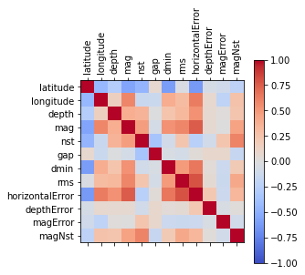

```python
#plot correlation matrix
earthquakes_corr = earthquakes.corr()
print (earthquakes_corr)
plt.matshow(earthquakes_corr,cmap='coolwarm', vmin=-1, vmax=1)
plt.xticks(range(len(earthquakes_corr)), earthquakes_corr.columns, rotation = 'vertical')
plt.yticks(range(len(earthquakes_corr.columns)), earthquakes_corr.columns)
plt.colorbar()
plt.show()
```

I then created a scatter chart matrix, the output of which does not show any obvious trends or patterns.

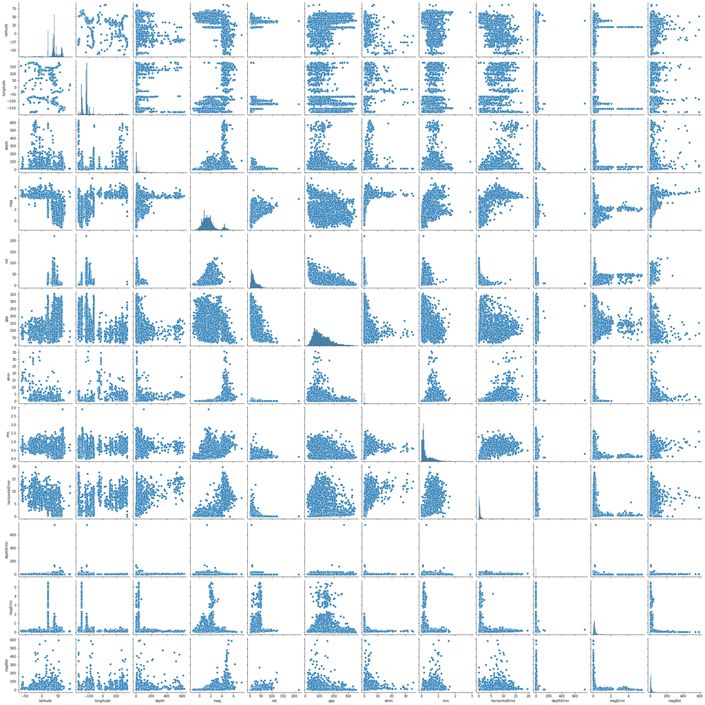

```python
sns.pairplot(earthquakes)
```

### World Map of Seismic Events in the Past 30 days

I plotted the coordinates of the seismic events (mainly earthquakes) over a world map using geopandas.

I used a colour gradient of red to indicate the magnitude of the event. The darker the red, the greater the magnitude.

The output shows that frequency and magnitude of earthquakes seem to be concentrated around certain areas.

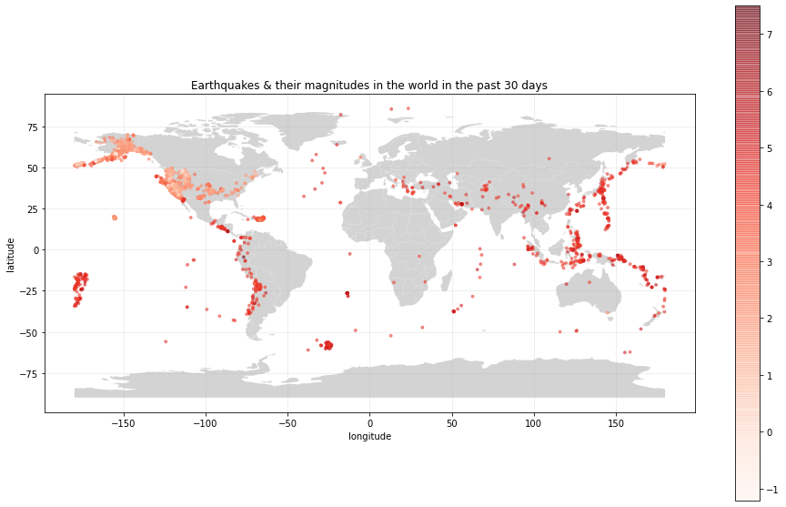

```python
#plot earthquake coordinates on world map
world = gpd.read_file(gpd.datasets.get_path('naturalearth_lowres'))
fig, ax = plt.subplots(figsize = (16,10))
world.plot(color = 'lightgrey', ax = ax)
earthquakes.plot(x = 'longitude', y = 'latitude', kind = 'scatter', c = earthquakes.mag , cmap = 'Reds', alpha = 0.5, marker = 'o', s=8, title ='Earthquakes & their magnitudes in the world in the past 30 days', ax = ax)
ax.grid(alpha = 0.25)
```

### Frequency of Earthquakes by Magnitude

I also produced a historgram of the earthquakes by magnitude. This shows that earthquakes of magnitude between 1 to 2 are the most frequent.

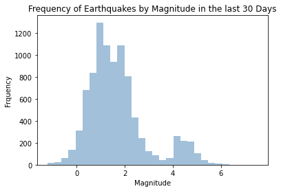

```python
plt.hist(earthquakes['mag'], bins=30, alpha=0.5, color='steelblue', edgecolor='none')
plt.title('Frequency of Earthquakes by Magnitude in the last 30 Days')
plt.xlabel('Magnitude')
plt.ylabel('Frquency')
plt.show()
```

### Boxplot of Earthquake Magnitudes

This plots the distribution of magnitudes, also reinforcing that earthquakes with magnitude between 1-2 are the most frequent.

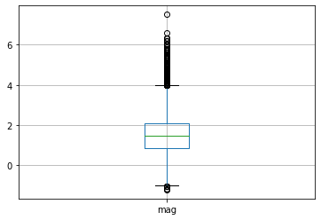

```python
earthquakes.boxplot(['mag'])
```

### Types of Seismic Events

The pie chart below shows a breakdown of the event types recorded in the dataset.

```
earthquake            8996
quarry blast           110
explosion               49
ice quake               26
sonic boom               1
other event              1
chemical explosion       1
Name: type, dtype: int64
```

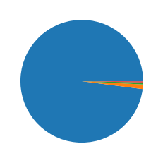

```python
type_freq = earthquakes['type'].value_counts()
print(type_freq)
plt.pie(type_freq)
plt.show()
```